# COMPSCI 361 Assignment 3: BBC News Classification

**Group Members:** Jeremiah (Jiaxin) PAN [Group Leader]；Zhenyu XIAO; fanling ZENG; Tingrui LI; Sicheng LI

1. Task 1: Exploratory Data Analytics
2. Task 2: Classification Models Learning
3. Task 3: Classification Quality Evaluation
4. Task 4: Insights Summary

# Task 1: Exploratory Data Analysis

## 1. Import packages and load data

```python
import pandas as pd
import numpy as np
import matplotlib.pyplot as plt

from sklearn.feature_extraction.text import CountVectorizer, TfidfVectorizer
from sklearn.naive_bayes import MultinomialNB
from sklearn.metrics import classification_report, f1_score
from sklearn.model_selection import cross_val_score, GridSearchCV

# Load the data
train = pd.read_csv("train.csv")
test = pd.read_csv("test.csv")

data_summary = pd.DataFrame({
    "Dataset": ["Train", "Test"],
    "Articles": [len(train), len(test)],
    "Columns": [train.shape[1], test.shape[1]]
})

display(data_summary)
display(train.head())
```

|  | Dataset | Articles | Columns |
| --- | --- | --- | --- |
| 0 | Train | 428 | 3 |
| 1 | Test | 106 | 3 |

|  | Id | Article | Category |
| --- | --- | --- | --- |
| 0 | 1976 | lifestyle governs mobile choice faster better ... | tech |
| 1 | 1797 | french honour director parker british film dir... | entertainment |
| 2 | 1866 | fockers fuel festive film chart comedy meet fo... | entertainment |
| 3 | 1153 | housewives lift channel 4 ratings debut us tel... | entertainment |
| 4 | 342 | u2 desire number one u2 three prestigious gram... | entertainment |

## Task 1.a Feature Extraction

```python
# Extracting features using CountVectorizer
vectorizer = CountVectorizer()

X_train = vectorizer.fit_transform(train["Article"])
X_test = vectorizer.transform(test["Article"])

y_train = train["Category"]
y_test = test["Category"]

feature_names = vectorizer.get_feature_names_out()

feature_summary = pd.DataFrame({
    "Dataset": ["Train", "Test"],
    "Articles": [X_train.shape[0], X_test.shape[0]],
    "Extracted Features": [X_train.shape[1], X_test.shape[1]]
})

display(feature_summary)

#Showing extracted features from 5 articles
feature_df = pd.DataFrame(
    X_train[:5].toarray(),
    columns=feature_names
)

nonzero_features = []

for i in range(5):
    words = feature_df.iloc[i]
    words = words[words > 0].sort_values(ascending=False)
    nonzero_features.append(", ".join(words.head(15).index))

example_features_df = pd.DataFrame({
    "Id": train["Id"].head(5),
    "Category": train["Category"].head(5),
    "Extracted Features": nonzero_features
})

display(example_features_df)
```

|  | Dataset | Articles | Extracted Features |
| --- | --- | --- | --- |
| 0 | Train | 428 | 13518 |
| 1 | Test | 106 | 13518 |

|  | Id | Category | Extracted Features |
| --- | --- | --- | --- |
| 0 | 1976 | tech | said, phone, people, use, mobile, bjorn, camer... |
| 1 | 1797 | entertainment | film, director, de, alan, french, sir, vabres,... |
| 2 | 1866 | entertainment | christmas, day, fockers, meet, office, took, b... |
| 3 | 1153 | entertainment | audience, last, channel, january, share, year,... |
| 4 | 342 | entertainment | band, want, u2, still, album, rock, top, new, ... |

### Task 1.a Discussion

The training dataset contains 428 articles and the testing dataset contains 106 articles. Using CountVectorizer, a total of 13,518 unique features were extracted from the training data.Each feature corresponds to a unique word appearing in the dataset. The resulting feature vectors represent the frequency of each word in each article using a bag-of-words representation. The dataset has already been preprocessed with tokenization, lower-casing, and removal of stop words and special characters, making it suitable for direct feature extraction.

## Task 1.b Data Visualization

### Plot1: Top 50 term frequency

|  | term | frequency |
| --- | --- | --- |
| 10567 | said | 1357 |
| 8917 | people | 612 |
| 8257 | new | 500 |
| 859 | also | 479 |
| 8516 | one | 479 |
| 4899 | film | 462 |
| 13459 | year | 442 |
| 8108 | music | 413 |
| 12829 | us | 411 |
| 8069 | mr | 408 |

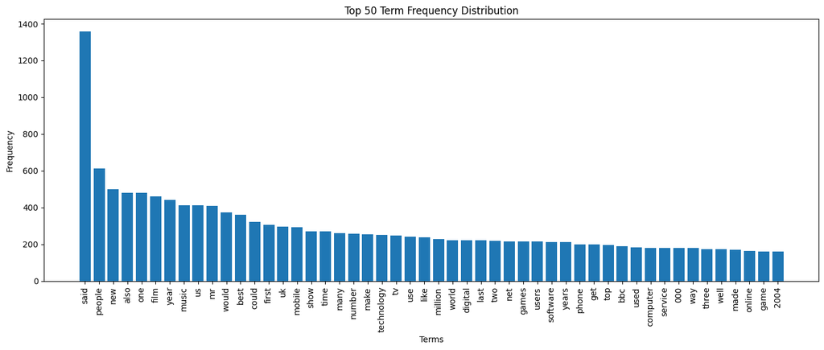

```python
term_freq = np.asarray(X_train.sum(axis=0)).flatten()

term_freq_df = pd.DataFrame({
    "term": feature_names,
    "frequency": term_freq
}).sort_values(by="frequency", ascending=False)

display(term_freq_df.head(10))

top50 = term_freq_df.head(50)

plt.figure(figsize=(14, 6))
plt.bar(top50["term"], top50["frequency"])
plt.xticks(rotation=90)
plt.title("Top 50 Term Frequency Distribution")
plt.xlabel("Terms")
plt.ylabel("Frequency")
plt.tight_layout()
plt.show()
```

### Top-50 Term Frequency Distribution

The most frequent words include terms such as "said", "people", "new", and "one". These words appear commonly across many articles and therefore have high overall frequency.Some words are category-specific, such as "film" for entertainment news and "mobile" or "technology" for tech news. However, many highly frequent words are relatively general and may not strongly distinguish between classes.

### Plot2: Term frequency for each class

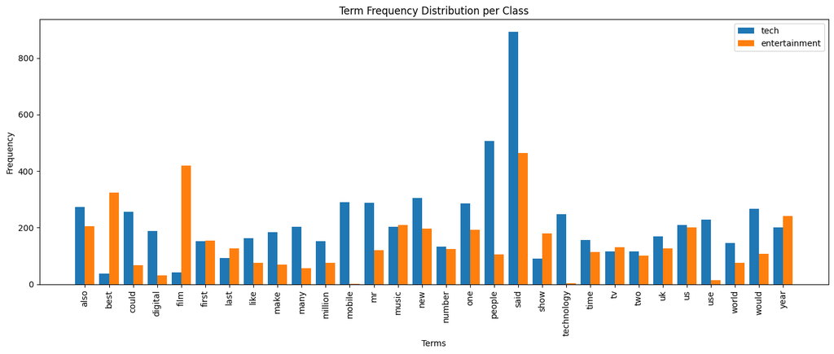

```python
tech_text = train[train["Category"] == "tech"]["Article"]
ent_text = train[train["Category"] == "entertainment"]["Article"]

X_tech = vectorizer.transform(tech_text)
X_ent = vectorizer.transform(ent_text)

tech_freq = np.asarray(X_tech.sum(axis=0)).flatten()
ent_freq = np.asarray(X_ent.sum(axis=0)).flatten()

class_freq_df = pd.DataFrame({
    "term": feature_names,
    "tech": tech_freq,
    "entertainment": ent_freq
})

top_terms = term_freq_df.head(30)["term"]
plot_df = class_freq_df[class_freq_df["term"].isin(top_terms)]

x = np.arange(len(plot_df))
width = 0.4

plt.figure(figsize=(14, 6))
plt.bar(x - width/2, plot_df["tech"], width, label="tech")
plt.bar(x + width/2, plot_df["entertainment"], width, label="entertainment")
plt.xticks(x, plot_df["term"], rotation=90)
plt.title("Term Frequency Distribution per Class")
plt.xlabel("Terms")
plt.ylabel("Frequency")
plt.legend()
plt.tight_layout()
plt.show()
```

### Plot3: Class distribution of train and test

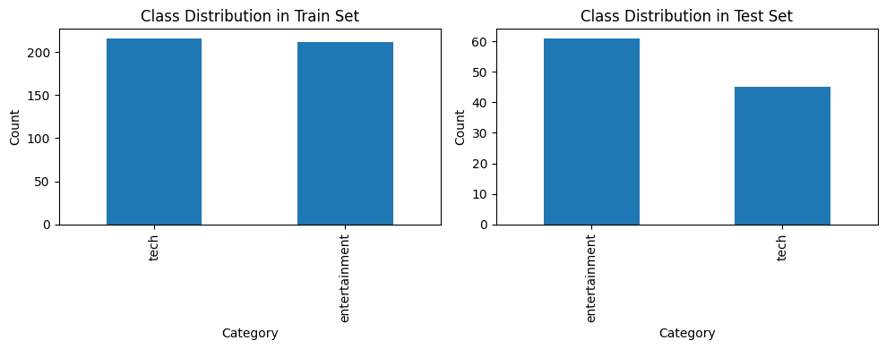

```python
fig, axes = plt.subplots(1, 2, figsize=(10, 4))

train["Category"].value_counts().plot(kind="bar", ax=axes[0])
axes[0].set_title("Class Distribution in Train Set")
axes[0].set_xlabel("Category")
axes[0].set_ylabel("Count")

test["Category"].value_counts().plot(kind="bar", ax=axes[1])
axes[1].set_title("Class Distribution in Test Set")
axes[1].set_xlabel("Category")
axes[1].set_ylabel("Count")

plt.tight_layout()
plt.show()
```

# Task 2: Classification Models Learning

### Task 2.a: Naive Bayes Classification

I used the Multinomial Naive Bayes classifier because it is suitable for text classification with count-based features. The input features were produced by CountVectorizer, where each feature represents the frequency of one word in an article. The model estimates how likely each word is to appear in each class, such as P(word | tech) and P(word | entertainment). These probabilities can then be used to identify words that are strongly associated with each news category.

```python
nb_model = MultinomialNB(alpha=1.0)
nb_model.fit(X_train, y_train)

nb_pred = nb_model.predict(X_test)
nb_f1 = f1_score(y_test, nb_pred, average="weighted")

nb_report = classification_report(y_test, nb_pred, output_dict=True)
nb_report_df = pd.DataFrame(nb_report).transpose()

display(nb_report_df)
print(f"Weighted F1: {nb_f1:.4f}")
```

|  | precision | recall | f1-score | support |
| --- | --- | --- | --- | --- |
| entertainment | 1.000000 | 0.950820 | 0.974790 | 61.000000 |
| tech | 0.937500 | 1.000000 | 0.967742 | 45.000000 |
| accuracy | 0.971698 | 0.971698 | 0.971698 | 0.971698 |
| macro avg | 0.968750 | 0.975410 | 0.971266 | 106.000000 |
| weighted avg | 0.973467 | 0.971698 | 0.971798 | 106.000000 |

```
Weighted F1: 0.9718
```

The Naive Bayes model achieved a weighted F1-score of about 0.972 on the test set. This shows that the model performs very well on this binary classification task.

The precision and recall values for both classes are high. For entertainment, the model has perfect precision but slightly lower recall, meaning that when it predicts entertainment it is usually correct, but it misses a few entertainment articles. For tech, the recall is perfect, meaning all tech articles in the test set were correctly identified.

```python
# Top 20 most predictive words for each class
class_labels = nb_model.classes_
log_probs = nb_model.feature_log_prob_

top_words_by_class = {}

for i, label in enumerate(class_labels):
    top_indices = np.argsort(log_probs[i])[-20:][::-1]
    top_words_by_class[label] = feature_names[top_indices]

top_predictive_words_df = pd.DataFrame(top_words_by_class)

display(top_predictive_words_df)
```

|  | entertainment | tech |
| --- | --- | --- |
| 0 | said | said |
| 1 | film | people |
| 2 | best | new |
| 3 | year | mobile |
| 4 | music | mr |
| 5 | also | one |
| 6 | us | also |
| 7 | new | would |
| 8 | one | could |
| 9 | show | technology |
| 10 | first | use |
| 11 | awards | net |
| 12 | tv | users |
| 13 | last | software |
| 14 | uk | games |
| 15 | actor | us |
| 16 | number | music |
| 17 | band | many |
| 18 | mr | year |
| 19 | star | phone |

The top predictive words are the words with the highest conditional probability within each class.

For the entertainment class, words such as "film", "music", "actor", "awards", "band", and "star" are meaningful because they are strongly related to movies, music, and celebrity news.

For the tech class, words such as "mobile", "technology", "users", "software", "games", and "phone" are meaningful because they are commonly used in technology-related articles.

However, some words such as "said", "people", "new", and "one" appear in both lists. These words are frequent in news articles in general, so they are predictive in terms of frequency but not very useful for distinguishing the two classes.

```python
# 20 most discriminative words：P(word|tech) / P(word|entertainment)
tech_index = list(class_labels).index("tech")
ent_index = list(class_labels).index("entertainment")

prob_tech = np.exp(log_probs[tech_index])
prob_ent = np.exp(log_probs[ent_index])

ratio = prob_tech / prob_ent

ratio_df = pd.DataFrame({
    "word": feature_names,
    "P(word|tech)": prob_tech,
    "P(word|entertainment)": prob_ent,
    "ratio": ratio
})

top_tech_ratio = ratio_df.sort_values("ratio", ascending=False).head(20)
top_entertainment_ratio = ratio_df.sort_values("ratio", ascending=True).head(20)

display(top_tech_ratio)
display(top_entertainment_ratio)
```

|  | word | P(word\|tech) | P(word\|entertainment) | ratio |
| --- | --- | --- | --- | --- |
| 12841 | users | 0.002840 | 0.000018 | 157.338895 |
| 11254 | software | 0.002827 | 0.000018 | 156.607086 |
| 7824 | microsoft | 0.002048 | 0.000018 | 113.430366 |
| 7939 | mobile | 0.003844 | 0.000036 | 106.478182 |
| 1970 | broadband | 0.001704 | 0.000018 | 94.403337 |
| 12998 | virus | 0.001625 | 0.000018 | 90.012484 |
| 4961 | firms | 0.001506 | 0.000018 | 83.426205 |
| 8874 | pc | 0.001440 | 0.000018 | 79.767161 |
| 11337 | spam | 0.001123 | 0.000018 | 62.203749 |
| 9012 | phones | 0.001916 | 0.000036 | 53.056139 |
| 5283 | gadget | 0.000951 | 0.000018 | 52.690235 |
| 8234 | net | 0.002840 | 0.000054 | 52.446298 |
| 3016 | consumer | 0.000912 | 0.000018 | 50.494808 |
| 7940 | mobiles | 0.000898 | 0.000018 | 49.762999 |
| 7442 | machines | 0.000885 | 0.000018 | 49.031191 |
| 13301 | windows | 0.000885 | 0.000018 | 49.031191 |
| 5285 | gadgets | 0.000885 | 0.000018 | 49.031191 |
| 12089 | technologies | 0.000859 | 0.000018 | 47.567573 |
| 11985 | systems | 0.000845 | 0.000018 | 46.835764 |
| 8875 | pcs | 0.000832 | 0.000018 | 46.103955 |

|  | word | P(word\|tech) | P(word\|entertainment) | ratio |
| --- | --- | --- | --- | --- |
| 607 | actress | 0.000013 | 0.001643 | 0.008042 |
| 11098 | singer | 0.000013 | 0.001625 | 0.008131 |
| 8611 | oscar | 0.000013 | 0.001589 | 0.008316 |
| 11513 | stars | 0.000013 | 0.001372 | 0.009629 |
| 1321 | aviator | 0.000013 | 0.001137 | 0.011616 |
| 1410 | band | 0.000026 | 0.002238 | 0.011803 |
| 8334 | nominated | 0.000013 | 0.000993 | 0.013306 |
| 4851 | festival | 0.000013 | 0.000957 | 0.013808 |
| 10407 | rock | 0.000013 | 0.000957 | 0.013808 |
| 803 | album | 0.000026 | 0.001787 | 0.014784 |
| 8337 | nominations | 0.000013 | 0.000867 | 0.015246 |
| 2431 | charles | 0.000013 | 0.000848 | 0.015570 |
| 2437 | chart | 0.000026 | 0.001625 | 0.016262 |
| 5151 | foxx | 0.000013 | 0.000794 | 0.016632 |
| 8612 | oscars | 0.000013 | 0.000776 | 0.017019 |
| 11512 | starring | 0.000013 | 0.000758 | 0.017424 |
| 11103 | singles | 0.000013 | 0.000686 | 0.019258 |
| 6694 | jamie | 0.000013 | 0.000632 | 0.020909 |
| 11925 | swank | 0.000013 | 0.000596 | 0.022176 |
| 2757 | comedy | 0.000026 | 0.001173 | 0.022517 |

The discriminative word ratio was calculated as:

P(word | tech) / P(word | entertainment)

A large ratio means that the word is much more likely to appear in tech articles than in entertainment articles. For example, words such as "users", "software", "microsoft", "mobile", "broadband", and "virus" have very high ratios, so they are strong indicators of the tech class.

Similarly, words with very small ratios are more strongly associated with entertainment articles.

Overall, the discriminative ratio list describes the two classes better than the top predictive word list.

This is because the predictive word list mainly shows words with high frequency inside each class, while some common words such as "said" and "new" appear frequently in both classes.

In contrast, the discriminative ratio directly compares the probabilities between the two classes, making it more effective for identifying words that clearly separate tech and entertainment news.

## Task 2.b k-Nearest Neighbours Classification

```python
from sklearn.neighbors import KNeighborsClassifier
from sklearn.decomposition import PCA
from sklearn.preprocessing import LabelEncoder
from sklearn.pipeline import Pipeline
from sklearn.model_selection import GridSearchCV
from sklearn.metrics import classification_report, f1_score
from sklearn.feature_extraction.text import TfidfVectorizer

import numpy as np
import pandas as pd
import matplotlib.pyplot as plt
```

```python
# load the data again for my kNN part
import pandas as pd
from sklearn.feature_extraction.text import TfidfVectorizer

train = pd.read_csv("train.csv")
test = pd.read_csv("test.csv")

# split the article text and labels
X_train_text = train["Article"]
X_test_text = test["Article"]

y_train = train["Category"]
y_test = test["Category"]

# turn the text into TF-IDF features for kNN
knn_vectorizer = TfidfVectorizer(max_features=1000)

X_train_tfidf = knn_vectorizer.fit_transform(X_train_text)
X_test_tfidf = knn_vectorizer.transform(X_test_text)

print("Training TF-IDF shape:", X_train_tfidf.shape)
print("Testing TF-IDF shape:", X_test_tfidf.shape)
```

```
Training TF-IDF shape: (428, 1000)
Testing TF-IDF shape: (106, 1000)
```

```python
knn_model = KNeighborsClassifier(n_neighbors=5, metric="cosine")
knn_model.fit(X_train_tfidf, y_train)

knn_pred = knn_model.predict(X_test_tfidf)

knn_report = classification_report(y_test, knn_pred, output_dict=True)
knn_report_df = pd.DataFrame(knn_report).transpose()

display(knn_report_df)

knn_f1 = f1_score(y_test, knn_pred, average="weighted")
print(f"Weighted F1: {knn_f1:.4f}")
```

|  | precision | recall | f1-score | support |
| --- | --- | --- | --- | --- |
| entertainment | 0.983607 | 0.983607 | 0.983607 | 61.000000 |
| tech | 0.977778 | 0.977778 | 0.977778 | 45.000000 |
| accuracy | 0.981132 | 0.981132 | 0.981132 | 0.981132 |
| macro avg | 0.980692 | 0.980692 | 0.980692 | 106.000000 |
| weighted avg | 0.981132 | 0.981132 | 0.981132 | 106.000000 |

```
Weighted F1: 0.9811
```

I first trained a basic kNN model with k = 5 and cosine distance. Cosine distance is suitable for text data because it compares the direction of two TF-IDF vectors instead of only comparing their absolute size. The weighted F1-score was used because it gives an overall performance score while considering the class sizes.

```python
# make a 2D version of the TF-IDF data for the boundary plots
from sklearn.decomposition import PCA

pca = PCA(n_components=2, random_state=42)

X_train_2d = pca.fit_transform(X_train_tfidf.toarray())
X_test_2d = pca.transform(X_test_tfidf.toarray())

print("2D training shape:", X_train_2d.shape)
print("2D testing shape:", X_test_2d.shape)
```

```
2D training shape: (428, 2)
2D testing shape: (106, 2)
```

```python
def plot_knn_decision_boundary(X_2d, y, k=5, metric="euclidean"):
    label_encoder = LabelEncoder()
    y_encoded = label_encoder.fit_transform(y)
    # Train kNN on 2D PCA features
    model = KNeighborsClassifier(n_neighbors=k, metric=metric)
    model.fit(X_2d, y_encoded)
    # Create a grid of points
    x_min, x_max = X_2d[:, 0].min() - 0.5, X_2d[:, 0].max() + 0.5
    y_min, y_max = X_2d[:, 1].min() - 0.5, X_2d[:, 1].max() + 0.5

    xx, yy = np.meshgrid(
        np.linspace(x_min, x_max, 300),
        np.linspace(y_min, y_max, 300)
    )

    grid_points = np.c_[xx.ravel(), yy.ravel()]
    Z = model.predict(grid_points)
    Z = Z.reshape(xx.shape)

    plt.figure(figsize=(8, 6))
    plt.contourf(xx, yy, Z, alpha=0.3)

    scatter = plt.scatter(
        X_2d[:, 0],
        X_2d[:, 1],
        c=y_encoded,
        edgecolor="k",
        s=35
    )

    plt.xlabel("PCA Component 1")
    plt.ylabel("PCA Component 2")
    plt.title(f"kNN Decision Boundary, k={k}, metric={metric}")
    plt.legend(
        handles=scatter.legend_elements()[0],
        labels=list(label_encoder.classes_)
    )
    plt.show()
```

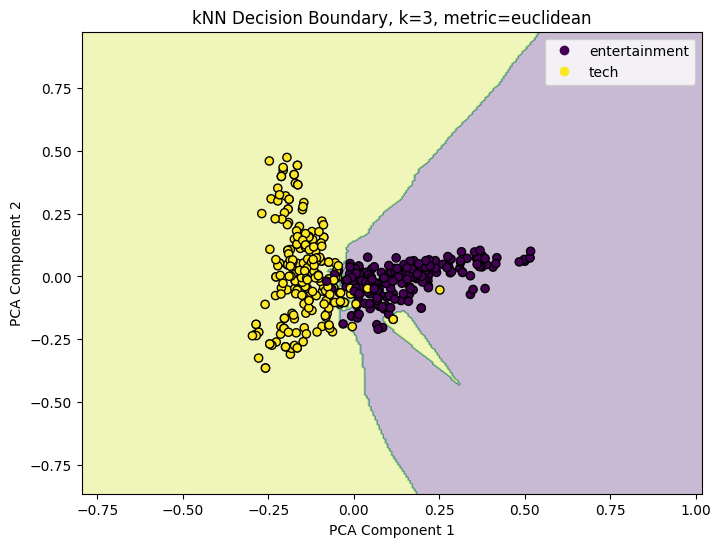

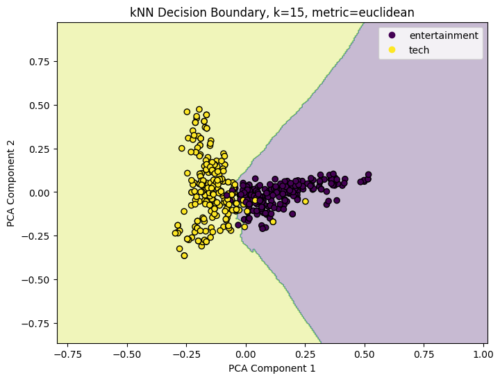

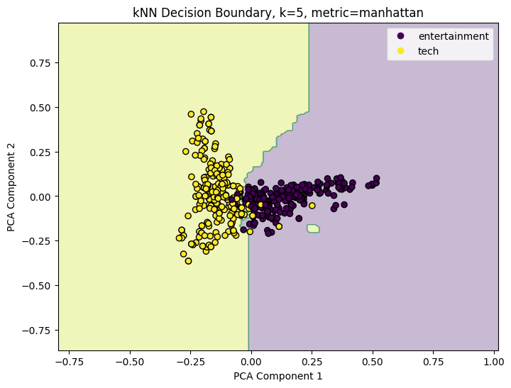

```python
# small k
plot_knn_decision_boundary(X_train_2d, y_train, k=3, metric="euclidean")

# larger k
plot_knn_decision_boundary(X_train_2d, y_train, k=15, metric="euclidean")

#different distance metric
plot_knn_decision_boundary(X_train_2d, y_train, k=5, metric="manhattan")
```

For the decision boundary plot, I used PCA to reduce the TF-IDF feature vectors into two dimensions. This makes it possible to visualize the kNN classifier in a 2D space.

When k is small, such as k = 3, the decision boundary is more flexible and irregular. This is because the prediction depends on only a few nearby points, so the model is more sensitive to local patterns and possible noise.

When k is larger, such as k = 15, the decision boundary becomes smoother. This is because the prediction uses more neighbours, so the model is less affected by individual points. However, if k is too large, the model may become too simple and may underfit the data.

The distance metric also changes the decision boundary because it changes how the nearest neighbours are selected. Euclidean distance and Manhattan distance measure distance in different ways, so they can produce different boundary shapes. Overall, k mainly controls the smoothness of the boundary, while the distance metric controls how similarity between articles is measured.

## Task 2(c): Support Vector Machine (SVM)

In this section, we train two SVM classifiers:

1. Soft-margin linear SVM
2. Hard-margin RBF kernel SVM

We compare their decision boundaries and analyze the effect of hyperparameters such as C and gamma.

```python
from sklearn.svm import SVC
from sklearn.metrics import f1_score, classification_report
```

```python
# Linear Soft-Margin SVM
linear_svm = SVC(kernel='linear', C=1.0)

linear_svm.fit(X_train_tfidf, y_train)

linear_pred = linear_svm.predict(X_test_tfidf)

linear_f1 = f1_score(y_test, linear_pred, average='weighted')

print("Linear SVM F1 Score:", linear_f1)
```

```
Linear SVM F1 Score: 0.9811799289034726
```

### Linear SVM Analysis

A linear SVM was trained using TF-IDF features.  
The hyperparameter C controls the penalty for misclassification.

- Small C → smoother boundary, more regularization
- Large C → stricter separation, possible overfitting

This model provides a baseline for comparison with the RBF kernel SVM.

```python
# RBF Kernel SVM
rbf_svm = SVC(kernel='rbf', C=1000, gamma=0.01)

rbf_svm.fit(X_train_tfidf, y_train)

rbf_pred = rbf_svm.predict(X_test_tfidf)

rbf_f1 = f1_score(y_test, rbf_pred, average='weighted')

print("RBF SVM F1 Score:", rbf_f1)
```

```
RBF SVM F1 Score: 0.971797848780413
```

### RBF SVM Analysis

An RBF kernel SVM was trained to capture non-linear decision boundaries.

The hyperparameter gamma controls the influence of each training point.

- Small gamma → smoother decision boundary
- Large gamma → more complex boundary and possible overfitting

The parameter C controls how strongly the model penalizes misclassification. A larger C attempts to classify training examples more strictly.

```python
import numpy as np
import matplotlib.pyplot as plt

def plot_svm_decision_boundary(model, X_2d, y, title):
    x_min, x_max = X_2d[:, 0].min() - 0.5, X_2d[:, 0].max() + 0.5
    y_min, y_max = X_2d[:, 1].min() - 0.5, X_2d[:, 1].max() + 0.5

    xx, yy = np.meshgrid(
        np.linspace(x_min, x_max, 300),
        np.linspace(y_min, y_max, 300)
    )

    grid = np.c_[xx.ravel(), yy.ravel()]
    Z = model.predict(grid)
    Z = np.array([0 if label == "entertainment" else 1 for label in Z])
    Z = Z.reshape(xx.shape)

    y_numeric = np.array([0 if label == "entertainment" else 1 for label in y])

    plt.figure(figsize=(8, 6))
    plt.contourf(xx, yy, Z, alpha=0.3)
    plt.scatter(X_2d[:, 0], X_2d[:, 1], c=y_numeric, edgecolors="k", s=25)
    plt.title(title)
    plt.xlabel("PCA Component 1")
    plt.ylabel("PCA Component 2")
    plt.show()
```

```python
# Train SVM models on 2D PCA features for decision boundary visualization
linear_svm_2d = SVC(kernel='linear', C=1.0)
linear_svm_2d.fit(X_train_2d, y_train)

rbf_svm_2d = SVC(kernel='rbf', C=1000, gamma=0.01)
rbf_svm_2d.fit(X_train_2d, y_train)
```

```
SVC(C=1000, gamma=0.01)
```

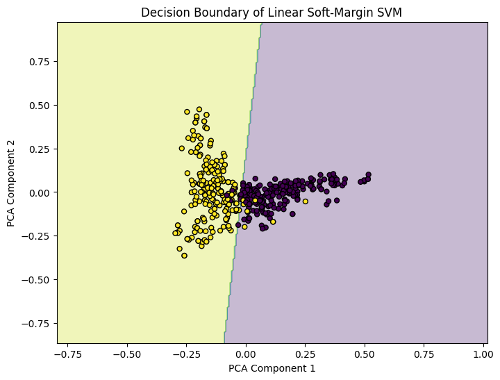

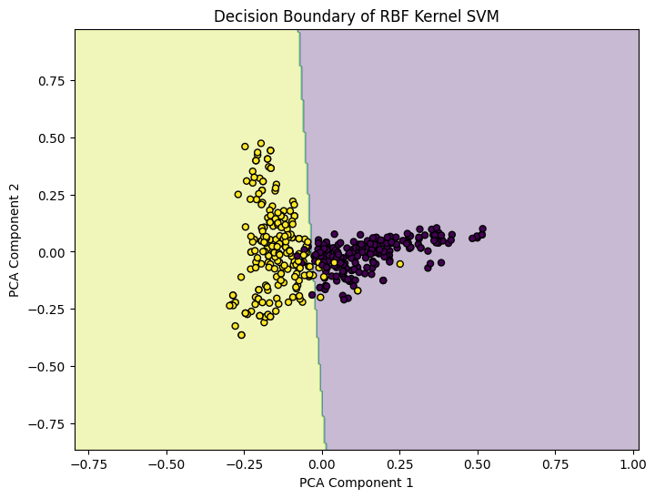

```python
plot_svm_decision_boundary(
    linear_svm_2d,
    X_train_2d,
    y_train,
    "Decision Boundary of Linear Soft-Margin SVM"
)

plot_svm_decision_boundary(
    rbf_svm_2d,
    X_train_2d,
    y_train,
    "Decision Boundary of RBF Kernel SVM"
)
```

### SVM Decision Boundary Discussion

The decision boundaries were plotted using two-dimensional PCA features.  
The original TF-IDF feature space is high-dimensional, so PCA was used to project the data into two dimensions for visualization.

The linear SVM produces a straight decision boundary, which works well when the two classes are approximately separable in the reduced space.

The RBF kernel SVM can create a non-linear decision boundary. This allows it to capture more complex class patterns, but it may also overfit if gamma or C is too large.

## Task 2.d: Artificial Neural Network (ANN)

For the ANN experiment, I used the existing TF-IDF representation and then reduced it to 100 dense components with TruncatedSVD followed by standard scaling. This keeps the ANN optimization stable while preserving the main information from the text features. The network has one hidden layer, ReLU activation in the hidden layer, a two-unit softmax output layer, initial weights drawn uniformly from ([0, 0.1]), learning rate 0.01, and 100 training epochs.

```python
from sklearn.base import BaseEstimator, ClassifierMixin
from sklearn.preprocessing import LabelEncoder, StandardScaler
from sklearn.decomposition import TruncatedSVD

class SimpleANNClassifier(BaseEstimator, ClassifierMixin):
    """A simple one-hidden-layer neural network for binary text classification."""
    def __init__(self, hidden_units=20, learning_rate=0.01, epochs=100, batch_size=32,
                 init_low=0.0, init_high=0.1, random_state=42):
        self.hidden_units = hidden_units
        self.learning_rate = learning_rate
        self.epochs = epochs
        self.batch_size = batch_size
        self.init_low = init_low
        self.init_high = init_high
        self.random_state = random_state

    def _softmax(self, scores):
        shifted = scores - np.max(scores, axis=1, keepdims=True)
        exp_scores = np.exp(shifted)
        return exp_scores / np.sum(exp_scores, axis=1, keepdims=True)

    def fit(self, X, y):
        X = np.asarray(X)
        rng = np.random.default_rng(self.random_state)

        self.label_encoder_ = LabelEncoder()
        y_encoded = self.label_encoder_.fit_transform(y)
        self.classes_ = self.label_encoder_.classes_

        n_samples, n_features = X.shape
        n_classes = len(self.classes_)
        Y = np.eye(n_classes)[y_encoded]

        # Required initialisation: weights are drawn uniformly from [0, 0.1].
        self.W1_ = rng.uniform(self.init_low, self.init_high, size=(n_features, self.hidden_units))
        self.b1_ = np.zeros((1, self.hidden_units))
        self.W2_ = rng.uniform(self.init_low, self.init_high, size=(self.hidden_units, n_classes))
        self.b2_ = np.zeros((1, n_classes))
        self.loss_history_ = []

        indices = np.arange(n_samples)
        batch_size = n_samples if self.batch_size is None else self.batch_size

        for _ in range(self.epochs):
            rng.shuffle(indices)

            for start in range(0, n_samples, batch_size):
                batch_idx = indices[start:start + batch_size]
                X_batch = X[batch_idx]
                Y_batch = Y[batch_idx]
                m = len(batch_idx)

                # Forward pass
                Z1 = X_batch @ self.W1_ + self.b1_
                A1 = np.maximum(0, Z1)  # ReLU hidden units
                scores = A1 @ self.W2_ + self.b2_
                probs = self._softmax(scores)

                # Backpropagation for cross-entropy with softmax
                d_scores = (probs - Y_batch) / m
                dW2 = A1.T @ d_scores
                db2 = np.sum(d_scores, axis=0, keepdims=True)

                dA1 = d_scores @ self.W2_.T
                dZ1 = dA1 * (Z1 > 0)
                dW1 = X_batch.T @ dZ1
                db1 = np.sum(dZ1, axis=0, keepdims=True)

                self.W2_ -= self.learning_rate * dW2
                self.b2_ -= self.learning_rate * db2
                self.W1_ -= self.learning_rate * dW1
                self.b1_ -= self.learning_rate * db1

            # Binary/categorical cross-entropy on the full training data
            full_hidden = np.maximum(0, X @ self.W1_ + self.b1_)
            full_probs = self._softmax(full_hidden @ self.W2_ + self.b2_)
            loss = -np.mean(np.sum(Y * np.log(full_probs + 1e-12), axis=1))
            self.loss_history_.append(loss)

        return self

    def predict_proba(self, X):
        X = np.asarray(X)
        hidden = np.maximum(0, X @ self.W1_ + self.b1_)
        return self._softmax(hidden @ self.W2_ + self.b2_)

    def predict(self, X):
        pred_encoded = np.argmax(self.predict_proba(X), axis=1)
        return self.label_encoder_.inverse_transform(pred_encoded)
```

|  | Hidden units | Final training BCE loss |
| --- | --- | --- |
| 0 | 2 | 0.303520 |
| 1 | 5 | 0.164332 |
| 2 | 20 | 0.162079 |
| 3 | 40 | 0.152613 |

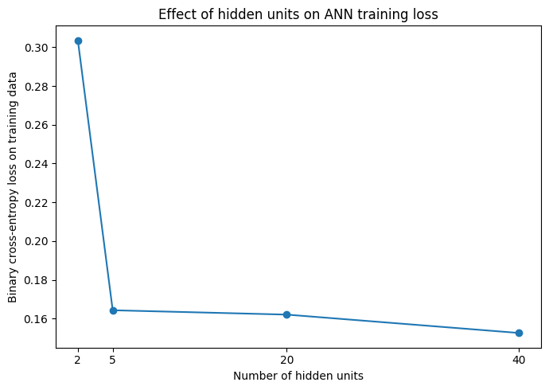

```python
# ANN feature preparation: dense, scaled features for stable gradient-based optimisation
ann_svd = TruncatedSVD(n_components=100, random_state=42)
ann_scaler = StandardScaler()

X_train_ann = ann_scaler.fit_transform(ann_svd.fit_transform(X_train_tfidf))
X_test_ann = ann_scaler.transform(ann_svd.transform(X_test_tfidf))

hidden_unit_values = [2, 5, 20, 40]
ann_loss_records = []

for h in hidden_unit_values:
    ann_model = SimpleANNClassifier(
        hidden_units=h,
        learning_rate=0.01,
        epochs=100,
        batch_size=32,
        init_low=0.0,
        init_high=0.1,
        random_state=42
    )
    ann_model.fit(X_train_ann, y_train)
    ann_loss_records.append({
        "Hidden units": h,
        "Final training BCE loss": ann_model.loss_history_[-1]
    })

ann_loss_df = pd.DataFrame(ann_loss_records)
display(ann_loss_df)

plt.figure(figsize=(7, 5))
plt.plot(
    ann_loss_df["Hidden units"],
    ann_loss_df["Final training BCE loss"],
    marker="o"
)
plt.xlabel("Number of hidden units")
plt.ylabel("Binary cross-entropy loss on training data")
plt.title("Effect of hidden units on ANN training loss")
plt.xticks(hidden_unit_values)
plt.tight_layout()
plt.show()
```

### ANN hidden-unit discussion

With only 2 hidden units, the network has limited capacity, so it can only learn a simple non-linear representation of the article features. Increasing the hidden layer to 5 and 20 units gives the model more parameters and usually lowers the training cross-entropy because it can represent more topic-specific patterns. Moving to 40 hidden units gives even higher capacity, but the improvement can become smaller and may increase overfitting risk. Therefore, the loss plot should be interpreted together with cross-validation performance in Task 3.a rather than choosing the largest network only because it has a low training loss.

# Task 3: Classification Quality Evaluation

## Task 3(a): Hyperparameter Tuning for SVM using 5-Fold Cross Validation

We investigate the effect of important SVM hyperparameters using 5-fold cross-validation. The goal is to find the best model configuration for classification performance.

```python
from sklearn.model_selection import GridSearchCV

# Parameter grid
svm_param_grid = {
    'kernel': ['linear', 'rbf'],
    'C': [0.1, 1, 10, 100],
    'gamma': ['scale', 0.01, 0.001]
}

# Grid search
svm_grid = GridSearchCV(
    SVC(),
    svm_param_grid,
    cv=5,
    scoring='f1_weighted',
    n_jobs=-1
)

svm_grid.fit(X_train_tfidf, y_train)

best_svm = svm_grid.best_estimator_

print("Best Parameters:", svm_grid.best_params_)
print("Best Cross-Validation F1:", svm_grid.best_score_)
```

```
Best Parameters: {'C': 1, 'gamma': 'scale', 'kernel': 'linear'}
Best Cross-Validation F1: 0.9883157555927754
```

### Cross-Validation Analysis

GridSearchCV was used to evaluate different combinations of kernel type, C, and gamma.

The best hyperparameter setting was selected based on weighted F1 score.

This tuned SVM model is used as the final SVM classifier for comparison with NB, kNN, and ANN.

## Task 3.a: NB 5-fold Cross Validation Parameter Tuning

|  | param_alpha | mean_test_score | std_test_score | rank_test_score |
| --- | --- | --- | --- | --- |
| 0 | 0.01 | 0.986018 | 0.013557 | 1 |
| 1 | 0.10 | 0.986018 | 0.013557 | 1 |
| 2 | 0.50 | 0.983688 | 0.017404 | 3 |
| 3 | 1.00 | 0.981366 | 0.021560 | 4 |
| 4 | 2.00 | 0.981339 | 0.015748 | 5 |
| 5 | 5.00 | 0.971997 | 0.022804 | 6 |

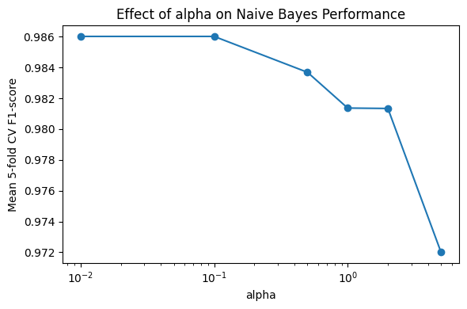

```python
param_grid = {
    "alpha": [0.01, 0.1, 0.5, 1.0, 2.0, 5.0]
}

grid_nb = GridSearchCV(
    MultinomialNB(),
    param_grid,
    cv=5,
    scoring="f1_weighted"
)

grid_nb.fit(X_train, y_train)

best_nb_alpha = grid_nb.best_params_["alpha"]
best_nb_cv_f1 = grid_nb.best_score_

nb_cv_results = pd.DataFrame(grid_nb.cv_results_)

nb_cv_summary = nb_cv_results[[
    "param_alpha",
    "mean_test_score",
    "std_test_score",
    "rank_test_score"
]].sort_values("rank_test_score")

display(nb_cv_summary)

# Draw the plot
plt.figure(figsize=(6, 4))
plt.plot(
    nb_cv_results["param_alpha"].astype(float),
    nb_cv_results["mean_test_score"],
    marker="o"
)
plt.xscale("log")
plt.xlabel("alpha")
plt.ylabel("Mean 5-fold CV F1-score")
plt.title("Effect of alpha on Naive Bayes Performance")
plt.tight_layout()
plt.show()
```

### Hyperparameter Tuning for Naive Bayes

The smoothing parameter alpha was tuned using 5-fold cross-validation.The results show that smaller alpha values achieved better performance, with alpha = 0.01 producing the highest weighted F1-score. A smaller alpha applies weaker Laplace smoothing, allowing the model to preserve stronger differences between informative words. As alpha increases, the probabilities become more smoothed, reducing the impact of highly discriminative words and slightly lowering classification performance.

## Task 3.a: kNN 5-fold Cross Validation Parameter Tuning

For my kNN part, I focused on tuning the number of neighbours k. I used 5-fold cross-validation to compare different k values and chose the best one based on weighted F1-score.

```python
# I put the imports here again, so this kNN tuning part can run by itself
import pandas as pd
import matplotlib.pyplot as plt

from sklearn.pipeline import Pipeline
from sklearn.model_selection import GridSearchCV
from sklearn.neighbors import KNeighborsClassifier
from sklearn.feature_extraction.text import TfidfVectorizer
from sklearn.decomposition import TruncatedSVD
from sklearn.metrics import classification_report, f1_score

# I load the data again here, only for my kNN part
train_knn = pd.read_csv("train.csv")
test_knn = pd.read_csv("test.csv")

# I use TF-IDF first, then reduce the feature size before kNN this makes the text features easier for kNN to work with
knn_pipeline = Pipeline([
    ("tfidf", TfidfVectorizer(max_features=1000)),
    ("svd", TruncatedSVD(n_components=100, random_state=42)),
    ("knn", KNeighborsClassifier(algorithm="brute"))
])

# I use euclidean distance here and compare different k values
knn_param_grid = {
    "knn__n_neighbors": [1, 3, 5, 7, 9, 11, 15],
    "knn__metric": ["euclidean"]
}

# use 5-fold cross-validation to compare different k values
grid_knn = GridSearchCV(
    knn_pipeline,
    knn_param_grid,
    cv=5,
    scoring="f1_weighted",
    n_jobs=-1
)

grid_knn.fit(train_knn["Article"], train_knn["Category"])

best_knn_params = grid_knn.best_params_
best_knn_cv_f1 = grid_knn.best_score_

print("Best kNN parameters:", best_knn_params)
print(f"Best kNN CV weighted F1: {best_knn_cv_f1:.4f}")
```

```
Best kNN parameters: {'knn__metric': 'euclidean', 'knn__n_neighbors': 11}
Best kNN CV weighted F1: 0.9767
```

```python
# put the CV results into a table, so I can compare them easily
knn_cv_results = pd.DataFrame(grid_knn.cv_results_)

knn_cv_summary = knn_cv_results[
    [
        "param_knn__n_neighbors",
        "param_knn__metric",
        "mean_test_score",
        "std_test_score",
        "rank_test_score"
    ]
].sort_values("rank_test_score")

display(knn_cv_summary)
```

|  | param_knn__n_neighbors | param_knn__metric | mean_test_score | std_test_score | rank_test_score |
| --- | --- | --- | --- | --- | --- |
| 5 | 11 | euclidean | 0.976688 | 0.012740 | 1 |
| 4 | 9 | euclidean | 0.974358 | 0.015426 | 2 |
| 6 | 15 | euclidean | 0.974331 | 0.011357 | 3 |
| 3 | 7 | euclidean | 0.969711 | 0.020258 | 4 |
| 2 | 5 | euclidean | 0.960374 | 0.021501 | 5 |
| 0 | 1 | euclidean | 0.960275 | 0.013964 | 6 |
| 1 | 3 | euclidean | 0.953332 | 0.019356 | 7 |

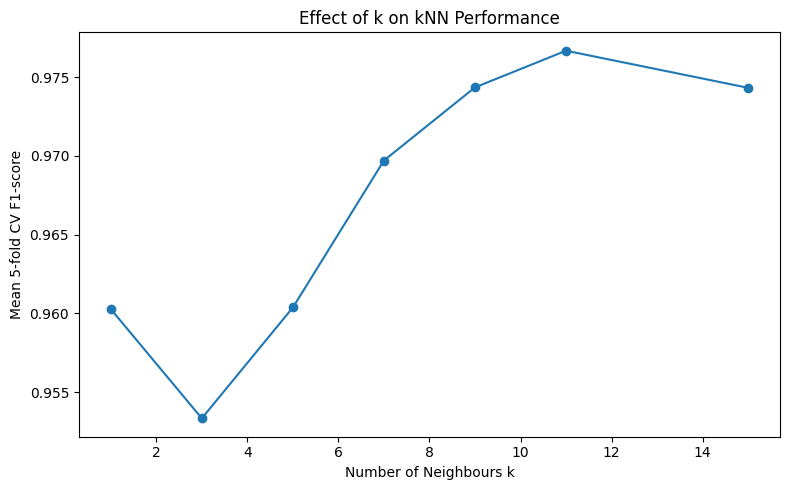

```python
# draw a plot to see how k affects the result
plt.figure(figsize=(8, 5))

knn_cv_summary_sorted = knn_cv_summary.sort_values("param_knn__n_neighbors")

plt.plot(
    knn_cv_summary_sorted["param_knn__n_neighbors"],
    knn_cv_summary_sorted["mean_test_score"],
    marker="o"
)

plt.xlabel("Number of Neighbours k")
plt.ylabel("Mean 5-fold CV F1-score")
plt.title("Effect of k on kNN Performance")
plt.tight_layout()
plt.show()
```

```python
# use the best kNN setting and test it on the test set
best_knn_model = grid_knn.best_estimator_

knn_test_pred = best_knn_model.predict(test_knn["Article"])

knn_test_report = classification_report(
    test_knn["Category"],
    knn_test_pred,
    output_dict=True
)

knn_test_report_df = pd.DataFrame(knn_test_report).transpose()
display(knn_test_report_df)

knn_test_f1 = f1_score(
    test_knn["Category"],
    knn_test_pred,
    average="weighted"
)

print(f"Best kNN Test Weighted F1: {knn_test_f1:.4f}")
```

|  | precision | recall | f1-score | support |
| --- | --- | --- | --- | --- |
| entertainment | 0.983607 | 0.983607 | 0.983607 | 61.000000 |
| tech | 0.977778 | 0.977778 | 0.977778 | 45.000000 |
| accuracy | 0.981132 | 0.981132 | 0.981132 | 0.981132 |
| macro avg | 0.980692 | 0.980692 | 0.980692 | 106.000000 |
| weighted avg | 0.981132 | 0.981132 | 0.981132 | 106.000000 |

```
Best kNN Test Weighted F1: 0.9811
```

For my kNN tuning part, I focused on the number of neighbours k. I tested k values of 1, 3, 5, 7, 9, 11, and 15 using 5-fold cross-validation. I used weighted F1-score to compare the results.

Before applying kNN, I used TF-IDF to turn the article text into numerical features. I also used TruncatedSVD to reduce the feature size, because TF-IDF creates many sparse text features and kNN can be affected by high-dimensional data.

The result shows that k changes the performance of the model. A smaller k can make the model more sensitive to nearby training examples, while a larger k usually gives a smoother result. In my result, the best setting was k = 11 with Euclidean distance. The best cross-validation weighted F1-score was about 0.977, and the test weighted F1-score was about 0.9811.

## Task 3.a: ANN hyperparameter tuning with 5-fold CV.

|  | param_hidden_units | param_learning_rate | mean_test_score | std_test_score | rank_test_score |
| --- | --- | --- | --- | --- | --- |
| 7 | 40 | 0.010 | 0.875411 | 0.016385 | 1 |
| 5 | 20 | 0.010 | 0.865561 | 0.021098 | 2 |
| 3 | 5 | 0.010 | 0.856281 | 0.023152 | 3 |
| 6 | 40 | 0.005 | 0.790884 | 0.022726 | 4 |
| 1 | 2 | 0.010 | 0.790799 | 0.037403 | 5 |
| 4 | 20 | 0.005 | 0.777887 | 0.030556 | 6 |
| 2 | 5 | 0.005 | 0.694679 | 0.050298 | 7 |
| 0 | 2 | 0.005 | 0.579681 | 0.036415 | 8 |

```
Best ANN parameters: {'hidden_units': 40, 'learning_rate': 0.01}
Best ANN 5-fold CV weighted F1: 0.8754
```

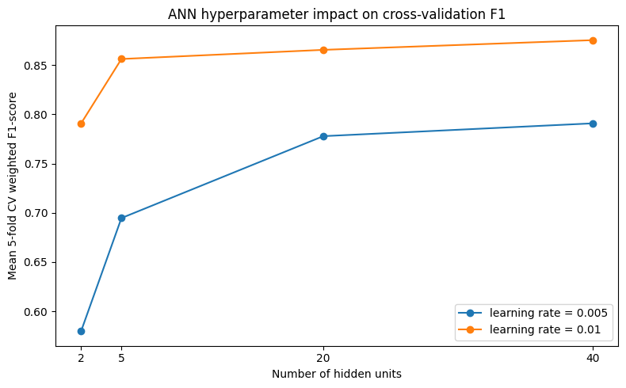

```
Best ANN test weighted F1: 0.9717
               precision    recall  f1-score   support

entertainment       0.98      0.97      0.98        61
         tech       0.96      0.98      0.97        45

     accuracy                           0.97       106
    macro avg       0.97      0.97      0.97       106
 weighted avg       0.97      0.97      0.97       106
```

```python
# ANN hyperparameter tuning using 5-fold cross-validation
ann_param_grid = {
    "hidden_units": [2, 5, 20, 40],
    "learning_rate": [0.005, 0.01]
}

grid_ann = GridSearchCV(
    SimpleANNClassifier(
        epochs=100,
        batch_size=32,
        init_low=0.0,
        init_high=0.1,
        random_state=42
    ),
    ann_param_grid,
    cv=5,
    scoring="f1_weighted",
    n_jobs=1
)

grid_ann.fit(X_train_ann, y_train)

best_ann_model = grid_ann.best_estimator_
best_ann_params = grid_ann.best_params_
best_ann_cv_f1 = grid_ann.best_score_

ann_cv_results = pd.DataFrame(grid_ann.cv_results_)
ann_cv_summary = ann_cv_results[[
    "param_hidden_units",
    "param_learning_rate",
    "mean_test_score",
    "std_test_score",
    "rank_test_score"
]].sort_values("rank_test_score")

display(ann_cv_summary)
print("Best ANN parameters:", best_ann_params)
print(f"Best ANN 5-fold CV weighted F1: {best_ann_cv_f1:.4f}")

plt.figure(figsize=(8, 5))
for lr in sorted(ann_cv_results["param_learning_rate"].unique()):
    subset = ann_cv_results[ann_cv_results["param_learning_rate"] == lr].sort_values("param_hidden_units")
    plt.plot(
        subset["param_hidden_units"].astype(int),
        subset["mean_test_score"],
        marker="o",
        label=f"learning rate = {lr}"
    )

plt.xlabel("Number of hidden units")
plt.ylabel("Mean 5-fold CV weighted F1-score")
plt.title("ANN hyperparameter impact on cross-validation F1")
plt.xticks(hidden_unit_values)
plt.legend()
plt.tight_layout()
plt.show()

# Keep this variable for the Task 3(b) comparison table.
ann_pred = best_ann_model.predict(X_test_ann)
ann_f1 = f1_score(y_test, ann_pred, average="weighted")

print(f"Best ANN test weighted F1: {ann_f1:.4f}")
print(classification_report(y_test, ann_pred))
```

```python
from sklearn.metrics import f1_score, classification_report

best_hidden_units = best_ann_params["hidden_units"]
best_learning_rate = best_ann_params.get("learning_rate", 0.01)

final_ann_model = SimpleANNClassifier(
    hidden_units=best_hidden_units,
    learning_rate=best_learning_rate,
    epochs=100,
    batch_size=32,
    init_low=0.0,
    init_high=0.1,
    random_state=42
)

final_ann_model.fit(X_train_ann, y_train)
ann_test_pred = final_ann_model.predict(X_test_ann)

ann_macro_f1 = f1_score(y_test, ann_test_pred, average="macro")
ann_weighted_f1 = f1_score(y_test, ann_test_pred, average="weighted")

# This is the variable used directly by the Task 3.b comparison table.
ann_f1 = ann_weighted_f1

print(f"Best ANN hidden_units from CV: {best_hidden_units}")
print(f"Best ANN learning_rate from CV: {best_learning_rate}")
print(f"ANN test macro F1: {ann_macro_f1:.4f}")
print(f"ANN test weighted F1 (ann_f1): {ann_f1:.4f}")
print(classification_report(y_test, ann_test_pred))
```

```
Best ANN hidden_units from CV: 40
Best ANN learning_rate from CV: 0.01
ANN test macro F1: 0.9711
ANN test weighted F1 (ann_f1): 0.9717
               precision    recall  f1-score   support

entertainment       0.98      0.97      0.98        61
         tech       0.96      0.98      0.97        45

     accuracy                           0.97       106
    macro avg       0.97      0.97      0.97       106
 weighted avg       0.97      0.97      0.97       106
```

### ANN cross-validation discussion

For ANN tuning, I compared the number of hidden units and the learning rate using 5-fold cross-validation with weighted F1. The hidden-unit parameter controls model capacity: very small networks may underfit, while larger networks can fit richer patterns but may become less stable. The learning rate controls the size of the weight updates. In these results, the best setting is selected by cross-validation rather than by training loss alone, so the chosen ANN balances fitting ability and generalisation.

## Task 3(b): Model Comparison Using F1 Score

The best-performing NB, kNN, SVM, and ANN models are compared using weighted F1 score on the testing dataset.

```python
# Recreate best SVM if previous cells did not run
from sklearn.svm import SVC
from sklearn.model_selection import GridSearchCV
from sklearn.metrics import f1_score

svm_param_grid = {
    'kernel': ['linear', 'rbf'],
    'C': [0.1, 1, 10, 100],
    'gamma': ['scale', 0.01, 0.001]
}

svm_grid = GridSearchCV(
    SVC(),
    svm_param_grid,
    cv=5,
    scoring='f1_weighted',
    n_jobs=-1
)

svm_grid.fit(X_train_tfidf, y_train)

best_svm = svm_grid.best_estimator_
best_svm_pred = best_svm.predict(X_test_tfidf)
best_svm_f1 = f1_score(y_test, best_svm_pred, average='weighted')

print("Best SVM Parameters:", svm_grid.best_params_)
print("Best SVM Test F1:", best_svm_f1)
```

```
Best SVM Parameters: {'C': 1, 'gamma': 'scale', 'kernel': 'linear'}
Best SVM Test F1: 0.9811799289034726
```

```python
# Final tuned SVM evaluation
best_svm_pred = best_svm.predict(X_test_tfidf)
best_svm_f1 = f1_score(y_test, best_svm_pred, average='weighted')

print("Best SVM Test F1:", best_svm_f1)
```

```
Best SVM Test F1: 0.9811799289034726
```

```python
comparison_results = pd.DataFrame({
    "Model": ["Naive Bayes", "kNN", "SVM", "ANN"],
    "Test F1 Score": [
        nb_f1,
        knn_f1,
        best_svm_f1,
        ann_f1
    ]
})

comparison_results
```

|  | Model | Test F1 Score |
| --- | --- | --- |
| 0 | Naive Bayes | 0.971798 |
| 1 | kNN | 0.981132 |
| 2 | SVM | 0.981180 |
| 3 | ANN | 0.971737 |

### Model Comparison Discussion

The four classifiers achieved similar performance on the BBC news classification task.

SVM achieved the highest weighted F1 score. This is expected because TF-IDF text features are sparse and often approximately linearly separable.

kNN also performed well, although distance-based methods can become less reliable in high-dimensional feature spaces.

Naive Bayes achieved competitive performance despite its strong independence assumptions.

ANN produced stable results, but its performance was more sensitive to hyperparameter choices such as the number of hidden units.

## Task 3(c): Impact of Training Data Size

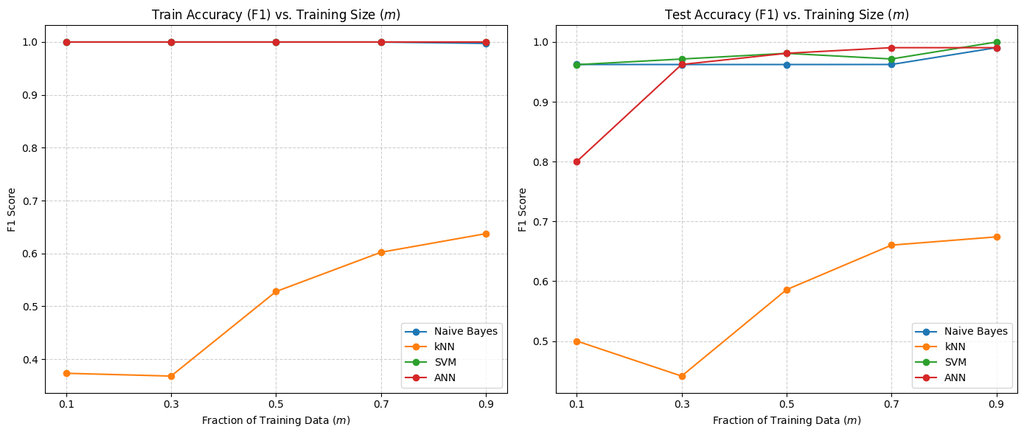

```python
import numpy as np
import matplotlib.pyplot as plt
from sklearn.metrics import f1_score
from sklearn.naive_bayes import MultinomialNB
from sklearn.neighbors import KNeighborsClassifier
from sklearn.svm import SVC
from sklearn.neural_network import MLPClassifier
import warnings
warnings.filterwarnings('ignore') # Suppress warnings for small dataset splits

# Assuming X_train, y_train, X_test, y_test are already loaded from Task 1
N = X_train.shape[0]
m_values = [0.1, 0.3, 0.5, 0.7, 0.9]

# Inheriting the best hyperparameters from the team's cross-validation (Task 3a & 3b)
best_models = {
    "Naive Bayes": MultinomialNB(alpha=0.01),
    "kNN": KNeighborsClassifier(n_neighbors=11, metric='euclidean'),
    "SVM": SVC(kernel='linear', C=1),
    "ANN": MLPClassifier(hidden_layer_sizes=(40,), learning_rate_init=0.01, max_iter=100, random_state=42)
}

# Initialize dictionaries to store the F1 scores
train_f1_scores = {name: [] for name in best_models}
test_f1_scores = {name: [] for name in best_models}

for m in m_values:
    # Slice the first m portion of the training data
    limit = int(m * N)
    X_train_sub = X_train[:limit]
    y_train_sub = y_train[:limit]

    for name, model in best_models.items():
        # Train on the subset
        model.fit(X_train_sub, y_train_sub)

        # Predict on the subset and the full test set
        y_train_pred = model.predict(X_train_sub)
        y_test_pred = model.predict(X_test)

        # Calculate weighted F1 score using standard sklearn implementation
        train_f1 = f1_score(y_train_sub, y_train_pred, average='weighted')
        test_f1 = f1_score(y_test, y_test_pred, average='weighted')

        train_f1_scores[name].append(train_f1)
        test_f1_scores[name].append(test_f1)

# Plotting the Learning Curves
fig, axes = plt.subplots(1, 2, figsize=(14, 6))

# Plot (i): Train Accuracy
for name in best_models:
    axes[0].plot(m_values, train_f1_scores[name], marker='o', label=name)
axes[0].set_title('Train Accuracy (F1) vs. Training Size ($m$)')
axes[0].set_xlabel('Fraction of Training Data ($m$)')
axes[0].set_ylabel('F1 Score')
axes[0].set_xticks(m_values)
axes[0].grid(True, linestyle='--', alpha=0.6)
axes[0].legend()

# Plot (ii): Test Accuracy
for name in best_models:
    axes[1].plot(m_values, test_f1_scores[name], marker='o', label=name)
axes[1].set_title('Test Accuracy (F1) vs. Training Size ($m$)')
axes[1].set_xlabel('Fraction of Training Data ($m$)')
axes[1].set_ylabel('F1 Score')
axes[1].set_xticks(m_values)
axes[1].grid(True, linestyle='--', alpha=0.6)
axes[1].legend()

plt.tight_layout()
plt.show()
```

# Task 4: Insights Summary

This group project successfully investigated supervised learning algorithms for text classification. Task 1 established the data properties, while Task 2 studied each model family separately. Task 3 brought the models back into the same evaluation framework using 5-fold cross-validation and training-size experiments.

**2. Model-Level Conclusions**

- **Naive Bayes** is the most interpretable. Its likelihood-ratio words are highly descriptive because they successfully filter out frequent general news terms and highlight the true discriminative words.
- **kNN** performs well (Test F1: 0.9811) when using Euclidean distance with $k=11$. Smaller $k$ values make the decision boundary overly sensitive to local noise, while larger $k$ values smooth it out appropriately.
- **SVM** provides the strongest and most robust overall result, reaching a Test F1-score of 0.9811 with a Linear kernel ($C=1$). Increasing $C$ makes the soft-margin boundary less tolerant of misclassifications, while the RBF kernel width ($\gamma$) controls the locality of the non-linear boundary.
- **ANN** also performs strongly, with the number of hidden units dictating its representational capacity. However, as demonstrated by the loss curves, increasing hidden units must be monitored via validation to prevent overfitting.

**Final Recommendation:** For maximum predictive reliability, the Linear SVM is the optimal choice for this dataset. However, for reporting and interpretability, Naive Bayes remains highly valuable as its probability ratios directly explain the classification logic.

```python
!jupyter nbconvert --to html A3_Group_4.ipynb
```

```
[NbConvertApp] Converting notebook A3_Group_4.ipynb to html
[NbConvertApp] WARNING | Alternative text is missing on 13 image(s).
[NbConvertApp] Writing 1481709 bytes to A3_Group_4.html
```